# Spline

DonghyunPark

2023-04-19

```r
library(tidyverse)
library(showtext)
library(GGally)
library(lubridate)
library(corrplot)
library(caret)
library(splines)
library(glmnet)
library(nortest)

font_add_google("Nanum Gothic", "nanum")
showtext_auto()
```

# Data loading

```r
data <- read.csv("/Users/donghyunpark/Documents/Seoul National University/3rd year 1st semester/Data mining/1차 프로젝트/1차 프로젝트 데이터/Dataset.csv", fileEncoding = "euc-kr")
```

# Str

```r
data$화재발생시_항목 <- as.factor(data$화재발생시_항목)
data$화재발생월_항목 <- as.factor(data$화재발생월_항목)
data <- data %>%
  filter(연면적 <= 426719,
         바닥면적 <= 426719,
         지하층수 <= 10)%>%
  filter(연면적 != 0)%>%
  select(-계절구분명)%>%
  mutate_if(is.character, as.factor) %>%
  mutate(연면적 = log(연면적 + 1, base = 10), 바닥면적 = log(바닥면적 + 1, base = 10), 화재진압시간 = log(화재진압시간 + 1, base = 10), 재산피해금액 = log(재산피해금액 + 1, base = 10)) %>%
  select(-내국인생활인구수, -일최대인구수, -일최소인구수, -장기체류외국인인구수, -단기체류외국인인구수, -일최대이동인구수, -서울외유입인구수, -동일자치구행정동간이동인구수, -자치구간이동인구수) %>%
  filter(시설장소대분류명 != "Other") %>%
  filter(최초착화물대분류명 != "Other")


data %>% str()
```

```
## 'data.frame':    15257 obs. of  34 variables:
##  $ 건물구조조              : Factor w/ 8 levels "Other","목조",..: 7 7 7 7 7 7 7 7 7 7 ...
##  $ 지상층수                : int  1 7 9 3 5 25 10 1 20 3 ...
##  $ 지하층수                : int  1 1 0 1 1 1 3 0 1 1 ...
##  $ 연면적                  : num  2.55 2.77 2.93 3.12 2.81 ...
##  $ 바닥면적                : num  2.42 2.08 2.1 2.55 1.99 ...
##  $ 재산피해금액            : num  2.63 1.49 2.3 3.2 1 ...
##  $ 화재발생연도            : int  2018 2018 2018 2018 2018 2018 2018 2018 2018 2018 ...
##  $ 화재발생월_항목         : Factor w/ 12 levels "1","2","3","4",..: 4 4 4 4 4 4 4 4 4 4 ...
##  $ 화재발생시_항목         : Factor w/ 24 levels "0","1","2","3",..: 3 5 5 8 9 10 13 13 14 17 ...
##  $ 요일                    : Factor w/ 7 levels "금요일","목요일",..: 2 2 2 2 2 2 2 2 2 2 ...
##  $ 출동소요시간            : int  151 211 269 137 171 152 282 191 68 407 ...
##  $ 화재진압시간            : num  3.47 1.79 0 3.48 1.79 ...
##  $ 시군구명                : Factor w/ 25 levels "강남구","강동구",..: 21 22 20 11 18 5 15 24 3 25 ...
##  $ 현장소방서거리          : int  1 3 3 0 3 2 1 1 4 5 ...
```

[output cut: 20 more lines]

# Spline modeling

## 10 fold CV

```r
set.seed(1)
k_fold_result <- createFolds(data$재산피해금액, k=10, list=TRUE, returnTrain = FALSE)
```

## Col을 연속형과 이산형으로 분류

```r
continuous_cols <- data %>%
  select(-재산피해금액, -화재발생연도) %>%
  select_if(is.numeric) %>%
  names()

factor_cols <-data %>%
  select(-재산피해금액) %>%
  select_if(is.factor) %>%
  names()

continuous_terms <- paste0(continuous_cols, collapse = " + ")
factor_terms <- paste0(factor_cols, collapse = " + ")
interaction_continuous_terms <- combn(continuous_cols, 2, FUN=function(x) paste0(x[1], ":", x[2]))
interaction_continuous_terms <- paste0(interaction_continuous_terms, collapse=" + ")
interaction_cont_factor_terms <- paste0(paste(factor_cols, continuous_cols, sep = ":"), collapse = " + ")
interaction_factor_terms <- combn(factor_cols, 2, FUN=function(x) paste0(x[1], ":", x[2]))
interaction_factor_terms <- paste0(interaction_factor_terms, collapse = " + ")
```

## MLR

```r
formula <- paste("재산피해금액 ~ ", factor_terms, "+", continuous_terms)

Fold_MSE <- c()
for (i in seq_along(k_fold_result)) {
  # Iteration number
  print(i)

  # i번째 fold를 테스트 데이터로 사용
  test <- data[k_fold_result[[i]], ]

  # 나머지 fold를 학습 데이터로 사용
  train <- data[-k_fold_result[[i]], ]

  model <- lm(formula = as.formula(formula), data = train)

  # i번째 fold에 대한 결과 저장
  Fold_MSE <- c(Fold_MSE, sum((test$재산피해금액-predict(model, test))^2)/(dim(test)[1]-dim(train)[1]+model$df.residual))
}
```

```
## [1] 1
## [1] 2
## [1] 3
## [1] 4
## [1] 5
## [1] 6
## [1] 7
## [1] 8
## [1] 9
## [1] 10
```

```r
mean(Fold_MSE)
```

```
## [1] 0.6974614
```

```r
model <- lm(formula = as.formula(formula), data = data)
RSS <- sum((summary(model)$residuals)^2) # Residual Sum of Squares

AIC <- dim(data)[1]*log(RSS/dim(data)[1]) + 2*(summary(model)$df[1]+1)
BIC <- dim(data)[1]*log(RSS/dim(data)[1]) + log(dim(data)[1])*(summary(model)$df[1]+1)

AIC
```

```
## [1] -6975.821
```

```r
BIC
```

```
## [1] -5922.495
```

```r
summary(model)$adj.r.squared
```

```
## [1] 0.3705876
```

```r
summary(model)$df
```

```
## [1]   137 15120   137
```

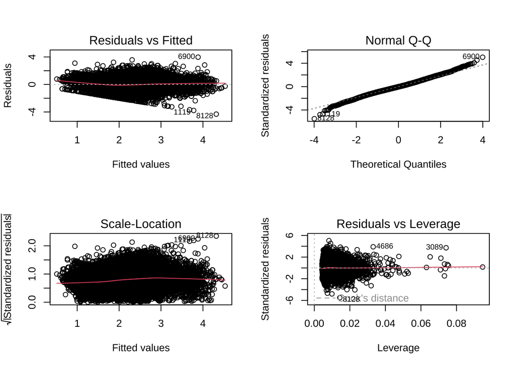

```r
par(mfrow = c(2,2))
plot(model)
```

## 2nd interaction added for continuous interactions MLR

```r
formula <- paste("재산피해금액 ~ ", factor_terms, "+", continuous_terms, "+", interaction_continuous_terms)

Fold_MSE <- c()
for (i in seq_along(k_fold_result)) {
  # Iteration number
  print(i)

  # i번째 fold를 테스트 데이터로 사용
  test <- data[k_fold_result[[i]], ]

  # 나머지 fold를 학습 데이터로 사용
  train <- data[-k_fold_result[[i]], ]

  model <- lm(formula = as.formula(formula), data = train)

  # i번째 fold에 대한 결과 저장
  Fold_MSE <- c(Fold_MSE, sum((test$재산피해금액-predict(model, test))^2)/(dim(test)[1]-dim(train)[1]+model$df.residual))
}
```

```
## [1] 1
## [1] 2
## [1] 3
## [1] 4
## [1] 5
## [1] 6
## [1] 7
## [1] 8
## [1] 9
## [1] 10
```

```r
mean(Fold_MSE)
```

```
## [1] 0.8005084
```

```r
model <- lm(formula = as.formula(formula), data = data)
RSS <- sum((summary(model)$residuals)^2) # Residual Sum of Squares

AIC <- dim(data)[1]*log(RSS/dim(data)[1]) + 2*(summary(model)$df[1]+1)
BIC <- dim(data)[1]*log(RSS/dim(data)[1]) + log(dim(data)[1])*(summary(model)$df[1]+1)

AIC
```

```
## [1] -6938.234
```

```r
BIC
```

```
## [1] -4594.966
```

```r
summary(model)$adj.r.squared
```

```
## [1] 0.3758837
```

```r
summary(model)$df
```

```
## [1]   306 14951   308
```

## 2nd interaction added for continuous interactions, continuous - factor interactions MLR

```r
formula <- paste("재산피해금액 ~ ", factor_terms, "+", continuous_terms, "+", interaction_continuous_terms, "+", interaction_cont_factor_terms)

Fold_MSE <- c()
for (i in seq_along(k_fold_result)) {
  # Iteration number
  print(i)

  # i번째 fold를 테스트 데이터로 사용
  test <- data[k_fold_result[[i]], ]

  # 나머지 fold를 학습 데이터로 사용
  train <- data[-k_fold_result[[i]], ]

  model <- lm(formula = as.formula(formula), data = train)

  # i번째 fold에 대한 결과 저장
  Fold_MSE <- c(Fold_MSE, sum((test$재산피해금액-predict(model, test))^2)/(dim(test)[1]-dim(train)[1]+model$df.residual))
}
```

```
## [1] 1
## [1] 2
## [1] 3
## [1] 4
## [1] 5
## [1] 6
## [1] 7
## [1] 8
## [1] 9
## [1] 10
```

```r
mean(Fold_MSE)
```

```
## [1] 0.947495
```

```r
model <- lm(formula = as.formula(formula), data = data)
RSS <- sum((summary(model)$residuals)^2) # Residual Sum of Squares

AIC <- dim(data)[1]*log(RSS/dim(data)[1]) + 2*(summary(model)$df[1]+1)
BIC <- dim(data)[1]*log(RSS/dim(data)[1]) + log(dim(data)[1])*(summary(model)$df[1]+1)

AIC
```

```
## [1] -7046.452
```

```r
BIC
```

```
## [1] -3268.219
```

```r
summary(model)$adj.r.squared
```

```
## [1] 0.387681
```

```r
summary(model)$df
```

```
## [1]   494 14763   504
```

## 2nd interaction added for all MLR

Impossible to Computate.

# Spline

## Natural Spline of degree of many degree of freedoms on continuous

```r
Fold_MSE_df <- vector(mode = "list", length = 8)
AIC <- c()
BIC <- c()
Adj.R.squared <- c()
params <- c()


for (df in 2:8){
  print(df)
  df_command <- paste(", df = ", df, ")")
  spline_df_command <- paste(df_command, " + splines::ns(")

  spline_continuous_terms <- paste0(continuous_cols, collapse = spline_df_command)
spline_continuous_terms <- paste("splines::ns(", spline_continuous_terms, df_command)

  formula <- paste("재산피해금액 ~ ", factor_terms, "+ 화재발생연도 +", spline_continuous_terms)

  for (i in seq_along(k_fold_result)) {

    # i번째 fold를 테스트 데이터로 사용
    test <- data[k_fold_result[[i]], ]

    # 나머지 fold를 학습 데이터로 사용
    train <- data[-k_fold_result[[i]], ]

    model <- lm(formula = as.formula(formula), data = train)

    # i번째 fold에 대한 결과 저장
    Fold_MSE_df[[df]] <- c(Fold_MSE_df[[df]], sum((test$재산피해금액-predict(model, test))^2)/(dim(test)[1]-dim(train)[1]+model$df.residual))
  }

  model <- lm(formula = as.formula(formula), data = data)
  RSS <- sum((summary(model)$residuals)^2) # Residual Sum of Squares

  AIC_model <- dim(data)[1]*log(RSS/dim(data)[1]) + 2*(summary(model)$df[1]+1)
  BIC_model <- dim(data)[1]*log(RSS/dim(data)[1]) + log(dim(data)[1])*(summary(model)$df[1]+1)

  AIC <- c(AIC, AIC_model)
  BIC <- c(BIC, BIC_model)
  Adj.R.squared <- c(Adj.R.squared, summary(model)$adj.r.squared)
  params <- c(params, summary(model)$df[1])

  print(summary(model)$df)
}
```

```
## [1] 2
## [1]   154 15103   157
## [1] 3
## [1]   170 15087   176
## [1] 4
## [1]   185 15072   195
## [1] 5
## [1]   199 15058   214
## [1] 6
## [1]   213 15044   233
## [1] 7
## [1]   227 15030   252
## [1] 8
## [1]   241 15016   271
```

```r
CVMSE <- c(mean(Fold_MSE_df[[2]]), mean(Fold_MSE_df[[3]]), mean(Fold_MSE_df[[4]]), mean(Fold_MSE_df[[5]]), mean(Fold_MSE_df[[6]]), mean(Fold_MSE_df[[7]]), mean(Fold_MSE_df[[8]]))
```

```r
AIC
```

```
## [1] -9558.681 -9685.340 -9828.341 -9852.139 -9840.413 -9822.730 -9806.953
```

```r
BIC
```

```
## [1] -8375.598 -8380.132 -8408.641 -8325.580 -8206.995 -8082.453 -7959.817
```

```r
Adj.R.squared
```

```
## [1] 0.4691959 0.4741301 0.4795418 0.4808236 0.4808944 0.4807621 0.4806942
```

```r
CVMSE
```

```
## [1] 0.5967147 0.5991435 0.6011714 0.6073040 0.6145111 0.6220298 0.6293442
```

```r
params
```

```
## [1] 154 170 185 199 213 227 241
```

### Plot

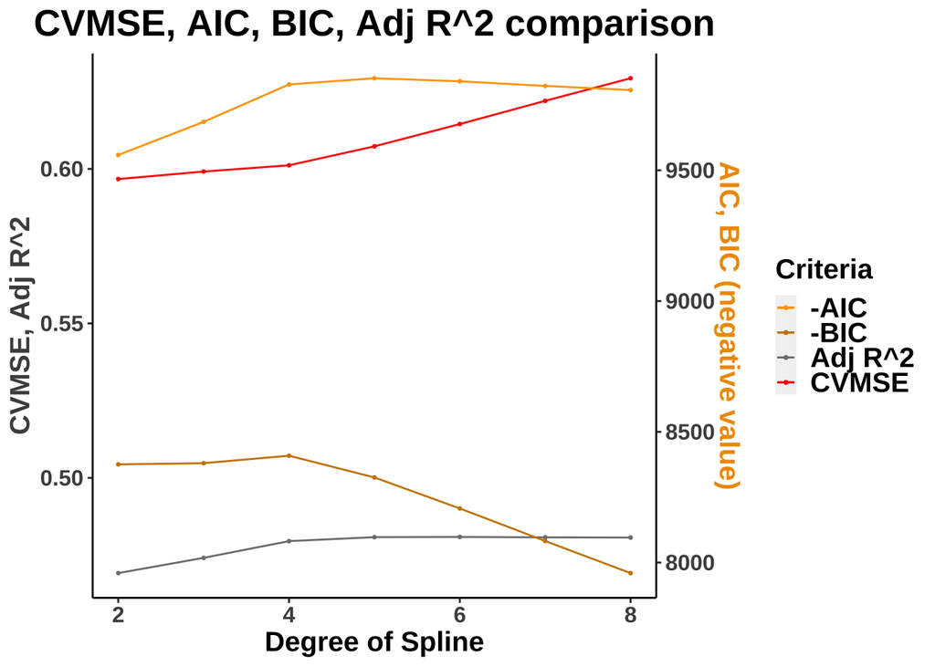

```r
df <- c(2,3,4,5,6,7,8)
max_first  <- max(CVMSE)   # Specify max of first y axis
max_second <- max(max(-AIC), max(-BIC)) # Specify max of second y axis
min_first  <- min(Adj.R.squared)   # Specify min of first y axis
min_second <- min(min(-AIC), min(-BIC)) # Specify min of second y axis

# scale and shift variables calculated based on desired mins and maxes
scale = (max_second - min_second)/(max_first - min_first)
shift = min_first - min_second

# Function to scale secondary axis
scale_function <- function(x){
  return ((x-min_first)*scale + min_second)
}

# Function to scale secondary variable values
inv_scale_function <- function(x){
  return ((x-min_second)/scale + min_first)
}

p <- as.data.frame(cbind(df, CVMSE, -AIC, -BIC, Adj.R.squared)) %>%
  ggplot(aes(x = df))+
  geom_point(aes(y = Adj.R.squared, color = "Adj R^2"), size = 0.5)+
  geom_point(aes(y = inv_scale_function(V3), color = "-AIC"), size = 0.5)+
  geom_point(aes(y = inv_scale_function(V4), color = "-BIC"), size = 0.5)+
  geom_point(aes(y = CVMSE, color = "CVMSE"), size = 0.5)+
  geom_line(aes(y = Adj.R.squared, color = "Adj R^2"))+
  geom_line(aes(y = CVMSE, color = "CVMSE"))+
  geom_line(aes(y = inv_scale_function(V3), color = "-AIC")) +
  geom_line(aes(y = inv_scale_function(V4), color = "-BIC")) +
  scale_y_continuous(
    # Features of the first axis
    name = "CVMSE, Adj R^2",

    # Add a second axis and specify its features
    sec.axis = sec_axis(~scale_function(.), name="AIC, BIC (negative value)"),
    n.breaks = 4
) +
  ggtitle("CVMSE, AIC, BIC, Adj R^2 comparison")+
  scale_color_manual(values = c("orange1", "orange3", "grey50", "red"))+
  theme(

    plot.title = element_text(size = 20, face = "bold", hjust = 0.5),
    axis.title.y = element_text(color = "gray30"),
    axis.title.y.right = element_text(color = "orange2"),
    panel.background = element_blank(),
    axis.line = element_line(colour = "black"),
    text = element_text(size = 15, face = "bold"),
    legend.key.size = unit(0.4, "cm"),
    legend.text = element_text(size = 15, face = "bold")
  )+
  labs(colour = "Criteria")+
  xlab("Degree of Spline")

p
```

```r
ggsave("/Users/donghyunpark/Documents/Seoul National University/3rd year 1st semester/Data mining/1차 프로젝트/1차 프로젝트 Rmd/1차 프로젝트 Visualize/Spline with no interaction plot.png", plot = p, width = 4, height = 2, dpi = 300)
```

### Natural Spline of degree of many degree of freedoms on continuous & continous term’s interaction

```r
Fold_MSE_df <- vector(mode = "list", length = 8)
AIC <- c()
BIC <- c()
Adj.R.squared <- c()
params <- c()


for (df in 1:8){
  print(df)
  df_command <- paste(", df = ", df, ")")
  spline_df_command <- paste(df_command, " + splines::ns(")

  spline_continuous_terms <- paste0(continuous_cols, collapse = spline_df_command)
spline_continuous_terms <- paste("splines::ns(", spline_continuous_terms, df_command)
  spline_interaction_continuous_terms <- combn(continuous_cols, 2, FUN=function(x) paste0(x[1], "*", x[2]))
  spline_interaction_continuous_terms <- paste0(spline_interaction_continuous_terms, collapse = spline_df_command)
  spline_interaction_continuous_terms <- paste("splines::ns(", spline_interaction_continuous_terms, df_command)

  formula <- paste("재산피해금액 ~ ", factor_terms, "+ 화재발생연도 +", spline_continuous_terms, "+", spline_interaction_continuous_terms)

  for (i in seq_along(k_fold_result)) {

    # i번째 fold를 테스트 데이터로 사용
    test <- data[k_fold_result[[i]], ]

    # 나머지 fold를 학습 데이터로 사용
    train <- data[-k_fold_result[[i]], ]

    model <- lm(formula = as.formula(formula), data = train)

    # i번째 fold에 대한 결과 저장
    Fold_MSE_df[[df]] <- c(Fold_MSE_df[[df]], sum((test$재산피해금액-predict(model, test))^2)/(dim(test)[1]-dim(train)[1]+model$df.residual))
  }
  model <- lm(formula = as.formula(formula), data = data)
  RSS <- sum((summary(model)$residuals)^2) # Residual Sum of Squares

  AIC_model <- dim(data)[1]*log(RSS/dim(data)[1]) + 2*(summary(model)$df[1]+1)
  BIC_model <- dim(data)[1]*log(RSS/dim(data)[1]) + log(dim(data)[1])*(summary(model)$df[1]+1)

  AIC <- c(AIC, AIC_model)
  BIC <- c(BIC, BIC_model)
  Adj.R.squared <- c(Adj.R.squared, summary(model)$adj.r.squared)

  print(summary(model)$df)
  params <- c(params, summary(model)$df[1])
}
```

```
## [1] 1
## [1]   307 14950   309
## [1] 2
## [1]   452 14805   499
## [1] 3
## [1]   597 14660   689
## [1] 4
## [1]   730 14527   879
## [1] 5
## [1]   859 14398  1069
## [1] 6
## [1]   992 14265  1259
## [1] 7
## [1]  1113 14144  1449
## [1] 8
## [1]  1245 14012  1639
```

```r
CVMSE <- c(mean(Fold_MSE_df[[1]]), mean(Fold_MSE_df[[2]]), mean(Fold_MSE_df[[3]]), mean(Fold_MSE_df[[4]]), mean(Fold_MSE_df[[5]]), mean(Fold_MSE_df[[6]]), mean(Fold_MSE_df[[7]]), mean(Fold_MSE_df[[8]]))
```

```r
AIC
```

```
## [1] -6956.111 -9398.639 -9476.226 -9518.630 -9447.482 -9336.740 -9241.094
## [8] -9119.775
```

```r
BIC
```

```
## [1] -4605.2108 -5940.9839 -4911.8157 -3939.0581 -2883.2796 -1757.3760  -738.1615
## [8]   390.6858
```

```r
Adj.R.squared
```

```
## [1] 0.3766546 0.4737654 0.4812114 0.4869382 0.4886425 0.4891004 0.4896489
## [8] 0.4896363
```

```r
CVMSE
```

```
## [1] 0.8002474 0.7812594 0.9000580 1.0590655 1.2743301 1.6138021 2.1068615
## [8] 3.1473465
```

```r
params
```

```
## [1]  307  452  597  730  859  992 1113 1245
```

### Plot

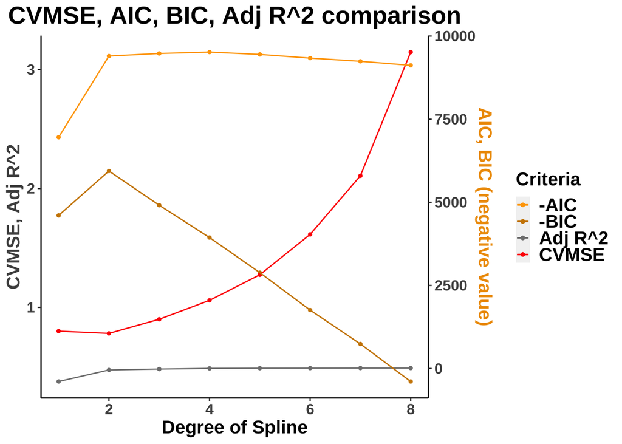

```r
df <- c(1,2,3,4, 5, 6, 7,8)
max_first  <- max(CVMSE)   # Specify max of first y axis
max_second <- max(max(-AIC), max(-BIC)) # Specify max of second y axis
min_first  <- min(Adj.R.squared)   # Specify min of first y axis
min_second <- min(min(-AIC), min(-BIC)) # Specify min of second y axis

# scale and shift variables calculated based on desired mins and maxes
scale = (max_second - min_second)/(max_first - min_first)
shift = min_first - min_second

# Function to scale secondary axis
scale_function <- function(x){
  return ((x-min_first)*scale + min_second)
}

# Function to scale secondary variable values
inv_scale_function <- function(x){
  return ((x-min_second)/scale + min_first)
}

p <- as.data.frame(cbind(df, CVMSE, -AIC, -BIC, Adj.R.squared)) %>%
  ggplot(aes(x = df))+
  geom_point(aes(y = Adj.R.squared, color = "Adj R^2"), size = 1)+
  geom_point(aes(y = inv_scale_function(V3), color = "-AIC"), size = 1)+
  geom_point(aes(y = inv_scale_function(V4), color = "-BIC"), size = 1)+
  geom_point(aes(y = CVMSE, color = "CVMSE"), size = 1)+
  geom_line(aes(y = Adj.R.squared, color = "Adj R^2"))+
  geom_line(aes(y = CVMSE, color = "CVMSE"))+
  geom_line(aes(y = inv_scale_function(V3), color = "-AIC")) +
  geom_line(aes(y = inv_scale_function(V4), color = "-BIC")) +
  scale_y_continuous(
    # Features of the first axis
    name = "CVMSE, Adj R^2",

    # Add a second axis and specify its features
    sec.axis = sec_axis(~scale_function(.), name="AIC, BIC (negative value)"),
    n.breaks = 4
) +
  ggtitle("CVMSE, AIC, BIC, Adj R^2 comparison")+
  scale_color_manual(values = c("orange1", "orange3", "grey50", "red"))+
  theme(

    plot.title = element_text(size = 20, face = "bold", hjust = 0.5),
    axis.title.y = element_text(color = "gray30"),
    axis.title.y.right = element_text(color = "orange2"),
    panel.background = element_blank(),
    axis.line = element_line(colour = "black"),
    text = element_text(size = 15, face = "bold"),
    legend.key.size = unit(0.4, "cm"),
    legend.text = element_text(size = 15, face = "bold")
  )+
  labs(colour = "Criteria")+
  xlab("Degree of Spline")

p
```

```r
ggsave("/Users/donghyunpark/Documents/Seoul National University/3rd year 1st semester/Data mining/1차 프로젝트/1차 프로젝트 Rmd/1차 프로젝트 Visualize/Spline with interaction plot.png", plot = p, width = 4, height = 2, dpi = 300)
```

### Natural Spline of degree of many degree of freedoms on continuous & continous term’s interaction, interactions all added

Computation So heavy. Do not get output.

# Spline with Lasso

```r
df = 1
grid <- 10^seq(5, -5, length = 100)

xfactor <- data[, factor_cols, drop = FALSE]

xyear <- data[["화재발생연도"]]

dummies <- lapply(xfactor, function(x) model.matrix(~x - 1, x))
# combine dummy variables with original data
xdummies <- do.call(cbind, dummies)


xcont <- data[, continuous_cols, drop = FALSE]
xspline <- lapply(seq_along(colnames(xcont)), function(i) {
  ns(xcont[, i], df = df)
})
xspline <- do.call(cbind, xspline)


CVMSE_lambda_1 <- rep(0, 100)

for(i in 1:10){
  # i번째 fold를 테스트 데이터로 사용
  test <- data[k_fold_result[[i]], ]

  # 나머지 fold를 학습 데이터로 사용
  train <- data[-k_fold_result[[i]], ]

  xspline.i <- xspline[-k_fold_result[[i]],]
  xdummies.i <- xdummies[-k_fold_result[[i]],]
  xspline._i <- xspline[k_fold_result[[i]],]
  xdummies._i <- xdummies[k_fold_result[[i]],]
  xyear.i <- xyear[-k_fold_result[[i]]]
  xyear._i <- xyear[k_fold_result[[i]]]

  x <- cbind(xdummies.i, xspline.i, xyear.i)
  y <- train$재산피해금액

  lasso.mod <- glmnet(x, y, alpha = 1, lambda = grid)
  for(j in 1:100){
    lasso.pred <- predict(lasso.mod, s = grid[j], newx = cbind(xdummies._i, xspline._i, xyear._i))
    lasso.coef <- predict(lasso.mod, type = "coefficients", s = grid[j])
    CVMSE_lambda_1[j] = CVMSE_lambda_1[j] + sum((lasso.pred - test$재산피해금액)^2)/(dim(test)[1] - sum(lasso.coef != 0))
  }
}

CVMSE_lambda_1 = CVMSE_lambda_1 / 10
```

```r
df = 2
grid <- 10^seq(5, -5, length = 100)

xfactor <- data[, factor_cols, drop = FALSE]

dummies <- lapply(xfactor, function(x) model.matrix(~x - 1, x))
# combine dummy variables with original data
xdummies <- do.call(cbind, dummies)


xcont <- data[, continuous_cols, drop = FALSE]
xspline <- lapply(seq_along(colnames(xcont)), function(i) {
  ns(xcont[, i], df = df)
})
xspline <- do.call(cbind, xspline)

xyear <- data[["화재발생연도"]]


CVMSE_lambda_2 <- rep(0, 100)

for(i in 1:10){
  # i번째 fold를 테스트 데이터로 사용
  test <- data[k_fold_result[[i]], ]

  # 나머지 fold를 학습 데이터로 사용
  train <- data[-k_fold_result[[i]], ]

  xspline.i <- xspline[-k_fold_result[[i]],]
  xdummies.i <- xdummies[-k_fold_result[[i]],]
  xspline._i <- xspline[k_fold_result[[i]],]
  xdummies._i <- xdummies[k_fold_result[[i]],]

  xyear.i <- xyear[-k_fold_result[[i]]]
  xyear._i <- xyear[k_fold_result[[i]]]


  x <- cbind(xdummies.i, xspline.i, xyear.i)
  y <- train$재산피해금액

  lasso.mod <- glmnet(x, y, alpha = 1, lambda = grid)
  for(j in 1:100){
    lasso.pred <- predict(lasso.mod, s = grid[j], newx = cbind(xdummies._i, xspline._i, xyear._i))
    lasso.coef <- predict(lasso.mod, type = "coefficients", s = grid[j])
    CVMSE_lambda_2[j] = CVMSE_lambda_2[j] + sum((lasso.pred - test$재산피해금액)^2)/(dim(test)[1] - sum(lasso.coef != 0))
  }
}

CVMSE_lambda_2 = CVMSE_lambda_2 / 10
```

```r
df = 3
grid <- 10^seq(5, -5, length = 100)

xfactor <- data[, factor_cols, drop = FALSE]

dummies <- lapply(xfactor, function(x) model.matrix(~x - 1, x))
# combine dummy variables with original data
xdummies <- do.call(cbind, dummies)


xcont <- data[, continuous_cols, drop = FALSE]
xspline <- lapply(seq_along(colnames(xcont)), function(i) {
  ns(xcont[, i], df = df)
})
xspline <- do.call(cbind, xspline)

xyear <- data[["화재발생연도"]]

CVMSE_lambda_3 <- rep(0, 100)

for(i in 1:10){
  # i번째 fold를 테스트 데이터로 사용
  test <- data[k_fold_result[[i]], ]

  # 나머지 fold를 학습 데이터로 사용
  train <- data[-k_fold_result[[i]], ]

  xspline.i <- xspline[-k_fold_result[[i]],]
  xdummies.i <- xdummies[-k_fold_result[[i]],]
  xspline._i <- xspline[k_fold_result[[i]],]
  xdummies._i <- xdummies[k_fold_result[[i]],]

  xyear.i <- xyear[-k_fold_result[[i]]]
  xyear._i <- xyear[k_fold_result[[i]]]

  x <- cbind(xdummies.i, xspline.i, xyear.i)
  y <- train$재산피해금액

  lasso.mod <- glmnet(x, y, alpha = 1, lambda = grid)
  for(j in 1:100){
    lasso.pred <- predict(lasso.mod, s = grid[j], newx = cbind(xdummies._i, xspline._i, xyear._i))
    lasso.coef <- predict(lasso.mod, type = "coefficients", s = grid[j])
    CVMSE_lambda_3[j] = CVMSE_lambda_3[j] + sum((lasso.pred - test$재산피해금액)^2)/(dim(test)[1] - sum(lasso.coef != 0))
  }
}

CVMSE_lambda_3 = CVMSE_lambda_3 / 10
```

```r
df = 4
grid <- 10^seq(5, -5, length = 100)

xfactor <- data[, factor_cols, drop = FALSE]

dummies <- lapply(xfactor, function(x) model.matrix(~x - 1, x))
# combine dummy variables with original data
xdummies <- do.call(cbind, dummies)


xcont <- data[, continuous_cols, drop = FALSE]
xspline <- lapply(seq_along(colnames(xcont)), function(i) {
  ns(xcont[, i], df = df)
})
xspline <- do.call(cbind, xspline)

xyear <- data[["화재발생연도"]]

CVMSE_lambda_4 <- rep(0, 100)

for(i in 1:10){
  # i번째 fold를 테스트 데이터로 사용
  test <- data[k_fold_result[[i]], ]

  # 나머지 fold를 학습 데이터로 사용
  train <- data[-k_fold_result[[i]], ]

  xspline.i <- xspline[-k_fold_result[[i]],]
  xdummies.i <- xdummies[-k_fold_result[[i]],]
  xspline._i <- xspline[k_fold_result[[i]],]
  xdummies._i <- xdummies[k_fold_result[[i]],]

  xyear.i <- xyear[-k_fold_result[[i]]]
  xyear._i <- xyear[k_fold_result[[i]]]


  x <- cbind(xdummies.i, xspline.i, xyear.i)
  y <- train$재산피해금액

  lasso.mod <- glmnet(x, y, alpha = 1, lambda = grid)
  for(j in 1:100){
    lasso.pred <- predict(lasso.mod, s = grid[j], newx = cbind(xdummies._i, xspline._i, xyear._i))
    lasso.coef <- predict(lasso.mod, type = "coefficients", s = grid[j])
    CVMSE_lambda_4[j] = CVMSE_lambda_4[j] + sum((lasso.pred - test$재산피해금액)^2)/(dim(test)[1] - sum(lasso.coef != 0))
  }
}

CVMSE_lambda_4 = CVMSE_lambda_4 / 10
```

```r
df = 5
grid <- 10^seq(5, -5, length = 100)

xfactor <- data[, factor_cols, drop = FALSE]

dummies <- lapply(xfactor, function(x) model.matrix(~x - 1, x))
# combine dummy variables with original data
xdummies <- do.call(cbind, dummies)


xcont <- data[, continuous_cols, drop = FALSE]
xspline <- lapply(seq_along(colnames(xcont)), function(i) {
  ns(xcont[, i], df = df)
})
xspline <- do.call(cbind, xspline)

xyear <- data[["화재발생연도"]]

CVMSE_lambda_5 <- rep(0, 100)

for(i in 1:10){
  # i번째 fold를 테스트 데이터로 사용
  test <- data[k_fold_result[[i]], ]

  # 나머지 fold를 학습 데이터로 사용
  train <- data[-k_fold_result[[i]], ]

  xspline.i <- xspline[-k_fold_result[[i]],]
  xdummies.i <- xdummies[-k_fold_result[[i]],]
  xspline._i <- xspline[k_fold_result[[i]],]
  xdummies._i <- xdummies[k_fold_result[[i]],]

  xyear.i <- xyear[-k_fold_result[[i]]]
  xyear._i <- xyear[k_fold_result[[i]]]


  x <- cbind(xdummies.i, xspline.i, xyear.i)
  y <- train$재산피해금액

  lasso.mod <- glmnet(x, y, alpha = 1, lambda = grid)
  for(j in 1:100){
    lasso.pred <- predict(lasso.mod, s = grid[j], newx = cbind(xdummies._i, xspline._i, xyear._i))
    lasso.coef <- predict(lasso.mod, type = "coefficients", s = grid[j])
    CVMSE_lambda_5[j] = CVMSE_lambda_5[j] + sum((lasso.pred - test$재산피해금액)^2)/(dim(test)[1] - sum(lasso.coef != 0))
  }
}

CVMSE_lambda_5 = CVMSE_lambda_5 / 10
```

```r
df = 6
grid <- 10^seq(5, -5, length = 100)

xfactor <- data[, factor_cols, drop = FALSE]

dummies <- lapply(xfactor, function(x) model.matrix(~x - 1, x))
# combine dummy variables with original data
xdummies <- do.call(cbind, dummies)


xcont <- data[, continuous_cols, drop = FALSE]
xspline <- lapply(seq_along(colnames(xcont)), function(i) {
  ns(xcont[, i], df = df)
})
xspline <- do.call(cbind, xspline)

xyear <- data[["화재발생연도"]]


CVMSE_lambda_6 <- rep(0, 100)

for(i in 1:10){
  # i번째 fold를 테스트 데이터로 사용
  test <- data[k_fold_result[[i]], ]

  # 나머지 fold를 학습 데이터로 사용
  train <- data[-k_fold_result[[i]], ]

  xspline.i <- xspline[-k_fold_result[[i]],]
  xdummies.i <- xdummies[-k_fold_result[[i]],]
  xspline._i <- xspline[k_fold_result[[i]],]
  xdummies._i <- xdummies[k_fold_result[[i]],]

  xyear.i <- xyear[-k_fold_result[[i]]]
  xyear._i <- xyear[k_fold_result[[i]]]


  x <- cbind(xdummies.i, xspline.i, xyear.i)
  y <- train$재산피해금액

  lasso.mod <- glmnet(x, y, alpha = 1, lambda = grid)
  for(j in 1:100){
    lasso.pred <- predict(lasso.mod, s = grid[j], newx = cbind(xdummies._i, xspline._i, xyear._i))
    lasso.coef <- predict(lasso.mod, type = "coefficients", s = grid[j])
    CVMSE_lambda_6[j] = CVMSE_lambda_6[j] + sum((lasso.pred - test$재산피해금액)^2)/(dim(test)[1] - sum(lasso.coef != 0))
  }
}

CVMSE_lambda_6 = CVMSE_lambda_6 / 10
```

```r
df = 7
grid <- 10^seq(5, -5, length = 100)

xfactor <- data[, factor_cols, drop = FALSE]

dummies <- lapply(xfactor, function(x) model.matrix(~x - 1, x))
# combine dummy variables with original data
xdummies <- do.call(cbind, dummies)


xcont <- data[, continuous_cols, drop = FALSE]
xspline <- lapply(seq_along(colnames(xcont)), function(i) {
  ns(xcont[, i], df = df)
})
xspline <- do.call(cbind, xspline)

xyear <- data[["화재발생연도"]]

CVMSE_lambda_7 <- rep(0, 100)

for(i in 1:10){
  # i번째 fold를 테스트 데이터로 사용
  test <- data[k_fold_result[[i]], ]

  # 나머지 fold를 학습 데이터로 사용
  train <- data[-k_fold_result[[i]], ]

  xspline.i <- xspline[-k_fold_result[[i]],]
  xdummies.i <- xdummies[-k_fold_result[[i]],]
  xspline._i <- xspline[k_fold_result[[i]],]
  xdummies._i <- xdummies[k_fold_result[[i]],]

  xyear.i <- xyear[-k_fold_result[[i]]]
  xyear._i <- xyear[k_fold_result[[i]]]


  x <- cbind(xdummies.i, xspline.i, xyear.i)
  y <- train$재산피해금액

  lasso.mod <- glmnet(x, y, alpha = 1, lambda = grid)
  for(j in 1:100){
    lasso.pred <- predict(lasso.mod, s = grid[j], newx = cbind(xdummies._i, xspline._i, xyear._i))
    lasso.coef <- predict(lasso.mod, type = "coefficients", s = grid[j])
    CVMSE_lambda_7[j] = CVMSE_lambda_7[j] + sum((lasso.pred - test$재산피해금액)^2)/(dim(test)[1] - sum(lasso.coef != 0))
  }
}

CVMSE_lambda_7 = CVMSE_lambda_7 / 10
```

```r
df = 8
grid <- 10^seq(5, -5, length = 100)

xfactor <- data[, factor_cols, drop = FALSE]

dummies <- lapply(xfactor, function(x) model.matrix(~x - 1, x))
# combine dummy variables with original data
xdummies <- do.call(cbind, dummies)


xcont <- data[, continuous_cols, drop = FALSE]
xspline <- lapply(seq_along(colnames(xcont)), function(i) {
  ns(xcont[, i], df = df)
})
xspline <- do.call(cbind, xspline)

xyear<- data[["화재발생연도"]]


CVMSE_lambda_8 <- rep(0, 100)

for(i in 1:10){
  # i번째 fold를 테스트 데이터로 사용
  test <- data[k_fold_result[[i]], ]

  # 나머지 fold를 학습 데이터로 사용
  train <- data[-k_fold_result[[i]], ]

  xspline.i <- xspline[-k_fold_result[[i]],]
  xdummies.i <- xdummies[-k_fold_result[[i]],]
  xspline._i <- xspline[k_fold_result[[i]],]
  xdummies._i <- xdummies[k_fold_result[[i]],]

  xyear.i <- xyear[-k_fold_result[[i]]]
  xyear._i <- xyear[k_fold_result[[i]]]

  x <- cbind(xdummies.i, xspline.i, xyear.i)
  y <- train$재산피해금액

  lasso.mod <- glmnet(x, y, alpha = 1, lambda = grid)
  for(j in 1:100){
    lasso.pred <- predict(lasso.mod, s = grid[j], newx = cbind(xdummies._i, xspline._i, xyear._i))
    lasso.coef <- predict(lasso.mod, type = "coefficients", s = grid[j])
    CVMSE_lambda_8[j] = CVMSE_lambda_8[j] + sum((lasso.pred - test$재산피해금액)^2)/(dim(test)[1] - sum(lasso.coef != 0))
  }
}

CVMSE_lambda_8 = CVMSE_lambda_8 / 10
```

### Find minimum lambda for each degree of freedum

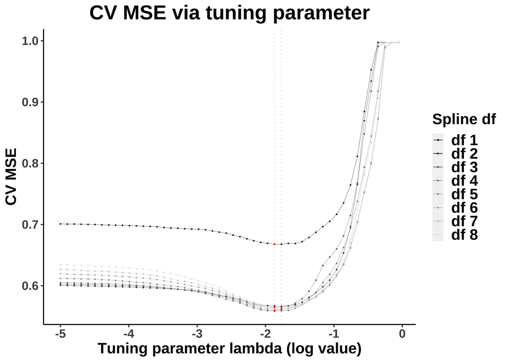

```r
CVMSE <- as.data.frame(cbind(grid, CVMSE_lambda_1, CVMSE_lambda_2, CVMSE_lambda_3, CVMSE_lambda_4, CVMSE_lambda_5, CVMSE_lambda_6, CVMSE_lambda_7, CVMSE_lambda_8))

df1_min <- CVMSE[which.min(CVMSE_lambda_1),]
df2_min <- CVMSE[which.min(CVMSE_lambda_2),]
df3_min <- CVMSE[which.min(CVMSE_lambda_3),]
df4_min <- CVMSE[which.min(CVMSE_lambda_4),]
df5_min <- CVMSE[which.min(CVMSE_lambda_5),]
df6_min <- CVMSE[which.min(CVMSE_lambda_6),]
df7_min <- CVMSE[which.min(CVMSE_lambda_7),]
df8_min <- CVMSE[which.min(CVMSE_lambda_8),]

p <- CVMSE%>%
  filter(grid < 1)%>%
  ggplot(aes(x = log(grid, base = 10)))+
  geom_point(aes(y = CVMSE_lambda_1, color = "df 1"), size = 0.1)+
  geom_line(aes(y = CVMSE_lambda_1, color = "df 1"), size = 0.1)+
  geom_point(aes(y = CVMSE_lambda_2, color = "df 2"), size = 0.1)+
  geom_line(aes(y = CVMSE_lambda_2, color = "df 2"), size = 0.1)+
  geom_point(aes(y = CVMSE_lambda_3, color = "df 3"), size = 0.1)+
  geom_line(aes(y = CVMSE_lambda_3, color = "df 3"), size = 0.1)+
  geom_point(aes(y = CVMSE_lambda_4, color = "df 4"), size = 0.1)+
  geom_line(aes(y = CVMSE_lambda_4, color = "df 4"), size = 0.1)+
  geom_point(aes(y = CVMSE_lambda_5, color = "df 5"), size = 0.1)+
  geom_line(aes(y = CVMSE_lambda_5, color = "df 5"), size = 0.1)+
  geom_point(aes(y = CVMSE_lambda_6, color = "df 6"), size = 0.1)+
  geom_line(aes(y = CVMSE_lambda_6, color = "df 6"), size = 0.1)+
  geom_point(aes(y = CVMSE_lambda_7, color = "df 7"), size = 0.1)+
  geom_line(aes(y = CVMSE_lambda_7, color = "df 7"), size = 0.1)+
  geom_point(aes(y = CVMSE_lambda_8, color = "df 8"), size = 0.1)+
  geom_line(aes(y = CVMSE_lambda_8, color = "df 8"), size = 0.1)+
  geom_point(data = df1_min, aes(x = log(grid, base = 10), y = CVMSE_lambda_1), color = "red", size = 0.1)+
  geom_point(data = df2_min, aes(x = log(grid, base = 10), y = CVMSE_lambda_2), color = "red", size = 0.1)+
  geom_point(data = df3_min, aes(x = log(grid, base = 10), y = CVMSE_lambda_3), color = "red", size = 0.1)+
  geom_point(data = df4_min, aes(x = log(grid, base = 10), y = CVMSE_lambda_4), color = "red", size = 0.1)+
  geom_point(data = df5_min, aes(x = log(grid, base = 10), y = CVMSE_lambda_5), color = "red", size = 0.1)+
  geom_point(data = df6_min, aes(x = log(grid, base = 10), y = CVMSE_lambda_6), color = "red", size = 0.1)+
  geom_point(data = df7_min, aes(x = log(grid, base = 10), y = CVMSE_lambda_7), color = "red", size = 0.1)+
  geom_point(data = df8_min, aes(x = log(grid, base = 10), y = CVMSE_lambda_8), color = "red", size = 0.1)+
  geom_vline(xintercept = -1.767677, color = "red", size = 0.1, linetype = "dotted")+
  geom_vline(xintercept = -1.868687, color = "red", size = 0.1, linetype = "dotted")+
  scale_color_manual(values = c("grey1", "grey20","grey40", "grey50", "grey60",
                                       "grey70", "grey80", "grey90"))+
  ggtitle("CV MSE via tuning parameter")+
  theme(
    plot.title = element_text(size = 20, face = "bold", hjust = 0.5),
    text = element_text(size = 15, face = "bold"),
    legend.key.size = unit(0.4, "cm"),
    legend.text = element_text(size = 15, face = "bold"),
    panel.background = element_blank(),
    axis.line = element_line(colour = "black")
  )+
  labs(colour = "Spline df")+
  xlab("Tuning parameter lambda (log value)")+
  ylab("CV MSE")
p
```

```r
ggsave("/Users/donghyunpark/Documents/Seoul National University/3rd year 1st semester/Data mining/1차 프로젝트/1차 프로젝트 Rmd/1차 프로젝트 Visualize/Spline Lasso tuning parameter.png", plot = p, width = 4, height = 2, dpi = 300)
```

### Adj R^2, AIC, BIC

```r
AIC <- c()
BIC <- c()
Adj.R.squared <- c()
CVMSE <- c(df2_min[[3]], df3_min[[4]], df4_min[[5]], df5_min[[6]], df6_min[[7]], df7_min[[8]], df8_min[[9]])
```

```r
df = 2
bestlam = df2_min[[1]]

xfactor <- data[, factor_cols, drop = FALSE]

dummies <- lapply(xfactor, function(x) model.matrix(~x - 1, x))
# combine dummy variables with original data
xdummies <- do.call(cbind, dummies)


xcont <- data[, continuous_cols, drop = FALSE]
xspline <- lapply(seq_along(colnames(xcont)), function(i) {
  ns(xcont[, i], df = df)
})
xspline <- do.call(cbind, xspline)

xyear <- data[["화재발생연도"]]

x <- cbind(xdummies, xspline, xyear)
y <- data$재산피해금액

lasso.mod <- glmnet(x, y, alpha = 1, lambda = bestlam)

lasso.pred <- predict(lasso.mod, s = bestlam, newx = cbind(xdummies, xspline, xyear))
lasso.coef <- predict(lasso.mod, type = "coefficients", s = bestlam)
RSS <- sum((lasso.pred - data$재산피해금액)^2)

AIC <- c(AIC, dim(data)[1]*log(RSS/dim(data)[1]) + 2*(sum(lasso.coef != 0)))
BIC <- c(BIC, dim(data)[1]*log(RSS/dim(data)[1]) + log(dim(data)[1])*(sum(lasso.coef != 0)))

SST <- sum((data$재산피해금액 - mean(data$재산피해금액))^2)
Adj.R.squared <- c(Adj.R.squared, 1- RSS/SST * (dim(data)[1])/(dim(data)[1] - sum(lasso.coef != 0)))
```

```r
df = 3
bestlam = df3_min[[1]]

xfactor <- data[, factor_cols, drop = FALSE]

dummies <- lapply(xfactor, function(x) model.matrix(~x - 1, x))
# combine dummy variables with original data
xdummies <- do.call(cbind, dummies)


xcont <- data[, continuous_cols, drop = FALSE]
xspline <- lapply(seq_along(colnames(xcont)), function(i) {
  ns(xcont[, i], df = df)
})
xspline <- do.call(cbind, xspline)

xyear <- data[["화재발생연도"]]

x <- cbind(xdummies, xspline, xyear)
y <- data$재산피해금액

lasso.mod <- glmnet(x, y, alpha = 1, lambda = bestlam)

lasso.pred <- predict(lasso.mod, s = bestlam, newx = cbind(xdummies, xspline, xyear))
lasso.coef <- predict(lasso.mod, type = "coefficients", s = bestlam)
RSS <- sum((lasso.pred - data$재산피해금액)^2)

AIC <- c(AIC, dim(data)[1]*log(RSS/dim(data)[1]) + 2*(sum(lasso.coef != 0)))
BIC <- c(BIC, dim(data)[1]*log(RSS/dim(data)[1]) + log(dim(data)[1])*(sum(lasso.coef != 0)))

SST <- sum((data$재산피해금액 - mean(data$재산피해금액))^2)
Adj.R.squared <- c(Adj.R.squared, 1- RSS/SST * (dim(data)[1])/(dim(data)[1] - sum(lasso.coef != 0)))
```

```r
df = 4
bestlam = df4_min[[1]]

xfactor <- data[, factor_cols, drop = FALSE]

dummies <- lapply(xfactor, function(x) model.matrix(~x - 1, x))
# combine dummy variables with original data
xdummies <- do.call(cbind, dummies)


xcont <- data[, continuous_cols, drop = FALSE]
xspline <- lapply(seq_along(colnames(xcont)), function(i) {
  ns(xcont[, i], df = df)
})
xspline <- do.call(cbind, xspline)

xyear <- data[["화재발생연도"]]

x <- cbind(xdummies, xspline, xyear)
y <- data$재산피해금액

lasso.mod <- glmnet(x, y, alpha = 1, lambda = bestlam)

lasso.pred <- predict(lasso.mod, s = bestlam, newx = cbind(xdummies, xspline, xyear))
lasso.coef <- predict(lasso.mod, type = "coefficients", s = bestlam)
RSS <- sum((lasso.pred - data$재산피해금액)^2)

AIC <- c(AIC, dim(data)[1]*log(RSS/dim(data)[1]) + 2*(sum(lasso.coef != 0)))
BIC <- c(BIC, dim(data)[1]*log(RSS/dim(data)[1]) + log(dim(data)[1])*(sum(lasso.coef != 0)))

SST <- sum((data$재산피해금액 - mean(data$재산피해금액))^2)
Adj.R.squared <- c(Adj.R.squared, 1- RSS/SST * (dim(data)[1])/(dim(data)[1] - sum(lasso.coef != 0)))
```

```r
df = 5
bestlam = df5_min[[1]]

xfactor <- data[, factor_cols, drop = FALSE]

dummies <- lapply(xfactor, function(x) model.matrix(~x - 1, x))
# combine dummy variables with original data
xdummies <- do.call(cbind, dummies)


xcont <- data[, continuous_cols, drop = FALSE]
xspline <- lapply(seq_along(colnames(xcont)), function(i) {
  ns(xcont[, i], df = df)
})
xspline <- do.call(cbind, xspline)

xyear <- data[["화재발생연도"]]

x <- cbind(xdummies, xspline, xyear)
y <- data$재산피해금액

lasso.mod <- glmnet(x, y, alpha = 1, lambda = bestlam)

lasso.pred <- predict(lasso.mod, s = bestlam, newx = cbind(xdummies, xspline, xyear))
lasso.coef <- predict(lasso.mod, type = "coefficients", s = bestlam)
RSS <- sum((lasso.pred - data$재산피해금액)^2)

AIC <- c(AIC, dim(data)[1]*log(RSS/dim(data)[1]) + 2*(sum(lasso.coef != 0)))
BIC <- c(BIC, dim(data)[1]*log(RSS/dim(data)[1]) + log(dim(data)[1])*(sum(lasso.coef != 0)))

SST <- sum((data$재산피해금액 - mean(data$재산피해금액))^2)
Adj.R.squared <- c(Adj.R.squared, 1- RSS/SST * (dim(data)[1])/(dim(data)[1] - sum(lasso.coef != 0)))
```

```r
df = 6
bestlam = df6_min[[1]]

xfactor <- data[, factor_cols, drop = FALSE]

dummies <- lapply(xfactor, function(x) model.matrix(~x - 1, x))
# combine dummy variables with original data
xdummies <- do.call(cbind, dummies)


xcont <- data[, continuous_cols, drop = FALSE]
xspline <- lapply(seq_along(colnames(xcont)), function(i) {
  ns(xcont[, i], df = df)
})
xspline <- do.call(cbind, xspline)
xyear <- data[["화재발생연도"]]

x <- cbind(xdummies, xspline, xyear)
y <- data$재산피해금액

lasso.mod <- glmnet(x, y, alpha = 1, lambda = bestlam)

lasso.pred <- predict(lasso.mod, s = bestlam, newx = cbind(xdummies, xspline, xyear))
lasso.coef <- predict(lasso.mod, type = "coefficients", s = bestlam)
RSS <- sum((lasso.pred - data$재산피해금액)^2)

AIC <- c(AIC, dim(data)[1]*log(RSS/dim(data)[1]) + 2*(sum(lasso.coef != 0)))
BIC <- c(BIC, dim(data)[1]*log(RSS/dim(data)[1]) + log(dim(data)[1])*(sum(lasso.coef != 0)))

SST <- sum((data$재산피해금액 - mean(data$재산피해금액))^2)
Adj.R.squared <- c(Adj.R.squared, 1- RSS/SST * (dim(data)[1])/(dim(data)[1] - sum(lasso.coef != 0)))
```

```r
df = 7
bestlam = df7_min[[1]]

xfactor <- data[, factor_cols, drop = FALSE]

dummies <- lapply(xfactor, function(x) model.matrix(~x - 1, x))
# combine dummy variables with original data
xdummies <- do.call(cbind, dummies)


xcont <- data[, continuous_cols, drop = FALSE]
xspline <- lapply(seq_along(colnames(xcont)), function(i) {
  ns(xcont[, i], df = df)
})
xspline <- do.call(cbind, xspline)

xyear <- data[["화재발생연도"]]

x <- cbind(xdummies, xspline, xyear)
y <- data$재산피해금액

lasso.mod <- glmnet(x, y, alpha = 1, lambda = bestlam)

lasso.pred <- predict(lasso.mod, s = bestlam, newx = cbind(xdummies, xspline, xyear))
lasso.coef <- predict(lasso.mod, type = "coefficients", s = bestlam)
RSS <- sum((lasso.pred - data$재산피해금액)^2)

AIC <- c(AIC, dim(data)[1]*log(RSS/dim(data)[1]) + 2*(sum(lasso.coef != 0)))
BIC <- c(BIC, dim(data)[1]*log(RSS/dim(data)[1]) + log(dim(data)[1])*(sum(lasso.coef != 0)))

SST <- sum((data$재산피해금액 - mean(data$재산피해금액))^2)
Adj.R.squared <- c(Adj.R.squared, 1- RSS/SST * (dim(data)[1])/(dim(data)[1] - sum(lasso.coef != 0)))
```

```r
df = 8
bestlam = df8_min[[1]]

xfactor <- data[, factor_cols, drop = FALSE]

dummies <- lapply(xfactor, function(x) model.matrix(~x - 1, x))
# combine dummy variables with original data
xdummies <- do.call(cbind, dummies)


xcont <- data[, continuous_cols, drop = FALSE]
xspline <- lapply(seq_along(colnames(xcont)), function(i) {
  ns(xcont[, i], df = df)
})
xspline <- do.call(cbind, xspline)

xyear <- data[["화재발생연도"]]

x <- cbind(xdummies, xspline, xyear)
y <- data$재산피해금액

lasso.mod <- glmnet(x, y, alpha = 1, lambda = bestlam)

lasso.pred <- predict(lasso.mod, s = bestlam, newx = cbind(xdummies, xspline, xyear))
lasso.coef <- predict(lasso.mod, type = "coefficients", s = bestlam)
RSS <- sum((lasso.pred - data$재산피해금액)^2)

AIC <- c(AIC, dim(data)[1]*log(RSS/dim(data)[1]) + 2*(sum(lasso.coef != 0)))
BIC <- c(BIC, dim(data)[1]*log(RSS/dim(data)[1]) + log(dim(data)[1])*(sum(lasso.coef != 0)))

SST <- sum((data$재산피해금액 - mean(data$재산피해금액))^2)
Adj.R.squared <- c(Adj.R.squared, 1- RSS/SST * (dim(data)[1])/(dim(data)[1] - sum(lasso.coef != 0)))
```

### Plot

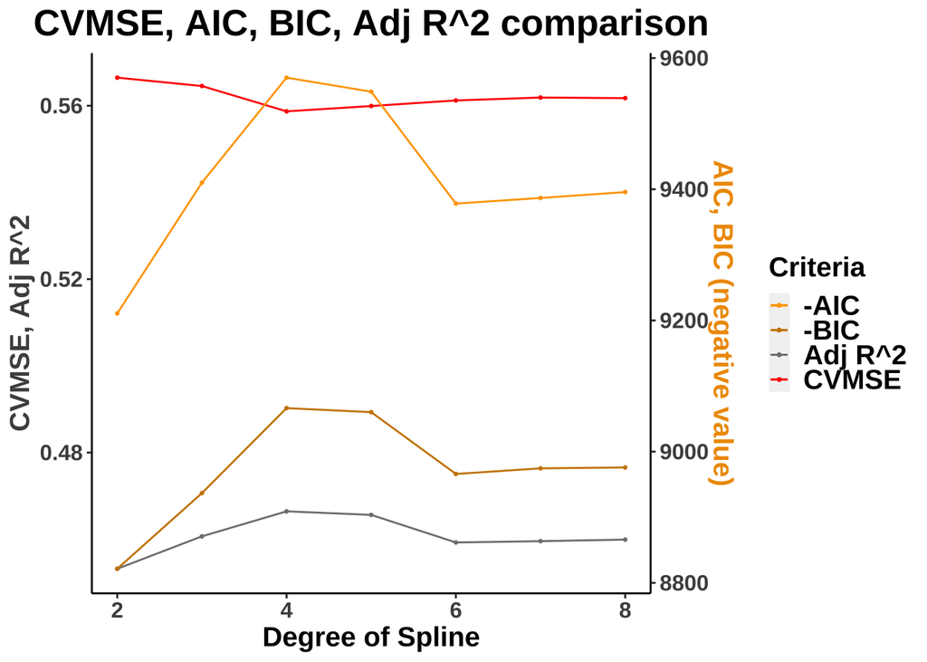

```r
df <- c(2,3,4,5,6,7,8)
max_first  <- max(CVMSE)   # Specify max of first y axis
max_second <- max(max(-AIC), max(-BIC)) # Specify max of second y axis
min_first  <- min(Adj.R.squared)   # Specify min of first y axis
min_second <- min(min(-AIC), min(-BIC)) # Specify min of second y axis

# scale and shift variables calculated based on desired mins and maxes
scale = (max_second - min_second)/(max_first - min_first)
shift = min_first - min_second

# Function to scale secondary axis
scale_function <- function(x){
  return ((x-min_first)*scale + min_second)
}

# Function to scale secondary variable values
inv_scale_function <- function(x){
  return ((x-min_second)/scale + min_first)
}

p <- as.data.frame(cbind(df, CVMSE, -AIC, -BIC, Adj.R.squared)) %>%
  ggplot(aes(x = df))+
  geom_point(aes(y = Adj.R.squared, color = "Adj R^2"), size = 0.5)+
  geom_point(aes(y = inv_scale_function(V3), color = "-AIC"), size = 0.5)+
  geom_point(aes(y = inv_scale_function(V4), color = "-BIC"), size = 0.5)+
  geom_point(aes(y = CVMSE, color = "CVMSE"), size = 0.5)+
  geom_line(aes(y = Adj.R.squared, color = "Adj R^2"))+
  geom_line(aes(y = CVMSE, color = "CVMSE"))+
  geom_line(aes(y = inv_scale_function(V3), color = "-AIC")) +
  geom_line(aes(y = inv_scale_function(V4), color = "-BIC")) +
  scale_y_continuous(
    # Features of the first axis
    name = "CVMSE, Adj R^2",

    # Add a second axis and specify its features
    sec.axis = sec_axis(~scale_function(.), name="AIC, BIC (negative value)"),
    n.breaks = 4
) +
  ggtitle("CVMSE, AIC, BIC, Adj R^2 comparison")+
  scale_color_manual(values = c("orange1", "orange3", "grey50", "red"))+
  theme(
    plot.title = element_text(size = 20, face = "bold", hjust = 0.5),
    axis.title.y = element_text(color = "gray30"),
    axis.title.y.right = element_text(color = "orange2"),
    panel.background = element_blank(),
    axis.line = element_line(colour = "black"),
    text = element_text(size = 15, face = "bold"),
    legend.key.size = unit(0.4, "cm"),
    legend.text = element_text(size = 15, face = "bold")
  )+
  labs(colour = "Criteria")+
  xlab("Degree of Spline")

p
```

```r
ggsave("/Users/donghyunpark/Documents/Seoul National University/3rd year 1st semester/Data mining/1차 프로젝트/1차 프로젝트 Rmd/1차 프로젝트 Visualize/Spline Lasso.png", plot = p, width = 4, height = 2, dpi = 300)
```

### In degree 4

```r
df = 4
bestlam = df4_min[[1]]

xfactor <- data[, factor_cols, drop = FALSE]

dummies <- lapply(xfactor, function(x) model.matrix(~x - 1, x))
# combine dummy variables with original data
xdummies <- do.call(cbind, dummies)


xcont <- data[, continuous_cols, drop = FALSE]
xspline <- lapply(seq_along(colnames(xcont)), function(i) {
  ns(xcont[, i], df = df)
})
xspline <- do.call(cbind, xspline)

xyear <- data[["화재발생연도"]]

x <- cbind(xdummies, xspline, xyear)
y <- data$재산피해금액

lasso.mod <- glmnet(x, y, alpha = 1, lambda = bestlam)

lasso.pred <- predict(lasso.mod, s = bestlam, newx = cbind(xdummies, xspline, xyear))
lasso.coef <- predict(lasso.mod, type = "coefficients", s = bestlam)
```

건물 구조조 : Other, 철골조, 철근콘크리트조

시간 : 1월, 5월, 0시, 5시, 12시, 19시~23시, 년도

구 : 강남구, 강서구, 관악구, 광진구, 노원구, 동대문구, 서대문구, 성동구, 종로구, 중구, 중랑구

발화열원 : Other, 기기 전도/복사열, 마찰/전도/복사, 미상, 불꽃/불티, 불꽃/스파크/정전기, 전기적 아크(단락)

발화요인대분류: 미상, 부주의

최초착화물 : 가구, 가연성 가스, 간판/치양막등, 기타, 미상, 식품, 쓰레기류, 위험물등, 침구/직물류

시설장소대분류명 : 공동주택, 교육시설, 산업시설, 생활서비스

화재보험의무가입대상여부 : Y

바닥면적(4), 출동소요시간(2), 화재진압시간(4), 현장소방서거리(1), 시간단위기온(2), 시간단위습도(4), 총생활인구수(4)

```r
sum(lasso.coef != 0)
```

```
## [1] 66
```

### Plot predict y vs y

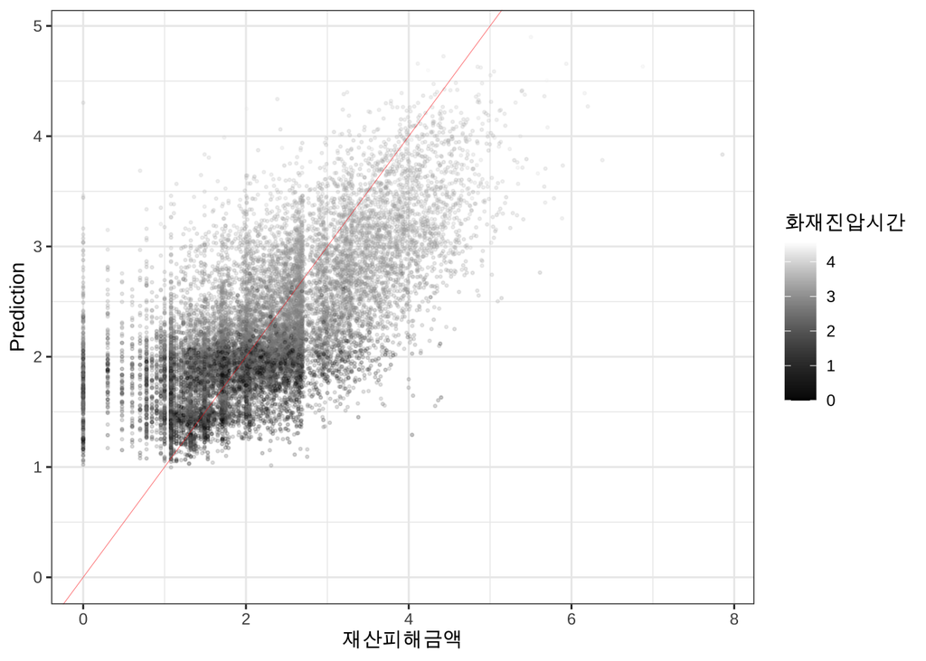

```r
Fitted <- as.data.frame(cbind(lasso.pred, data$재산피해금액, data$화재진압시간))
Fitted <- Fitted %>%
  rename("Prediction" = "s1", "재산피해금액" = "V2", "화재진압시간" = "V3")

p <- Fitted %>%
  ggplot() +
  geom_point(aes(x = 재산피해금액, y = Prediction, color = 화재진압시간), alpha = 0.2, size = 0.5)+
  geom_abline(color = "red", size = 0.1)+
  expand_limits(x = 0, y = 0)+
  scale_colour_gradient(low = "black", high = "white")+
  theme_bw()

p
```

```r
ggsave("/Users/donghyunpark/Documents/Seoul National University/3rd year 1st semester/Data mining/1차 프로젝트/1차 프로젝트 Rmd/1차 프로젝트 Visualize/재산피해금액_Prediction.png", plot = p, width = 4, height = 2, dpi = 300)
```

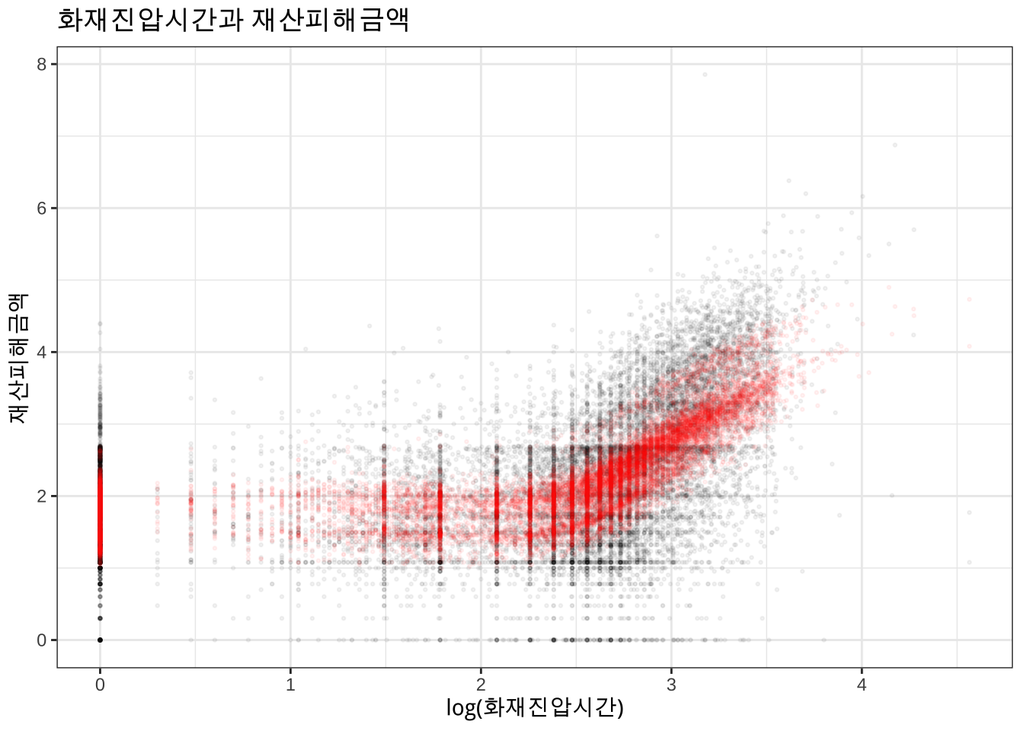

```r
p <- Fitted %>%
  ggplot()+
  geom_point(aes(x = 화재진압시간, y = 재산피해금액), alpha = 0.05, size= 0.5)+
  geom_point(aes(x = 화재진압시간, y = Prediction), alpha = 0.05, color = "red", size = 0.5)+
  theme_bw()+
  expand_limits(y = 0)+
  ggtitle("화재진압시간과 재산피해금액")+
  xlab("log(화재진압시간)")

p
```

```r
ggsave("/Users/donghyunpark/Documents/Seoul National University/3rd year 1st semester/Data mining/1차 프로젝트/1차 프로젝트 Rmd/1차 프로젝트 Visualize/화재진압시간-재산피해금액.png", plot = p, width = 4, height = 2, dpi = 300)
```

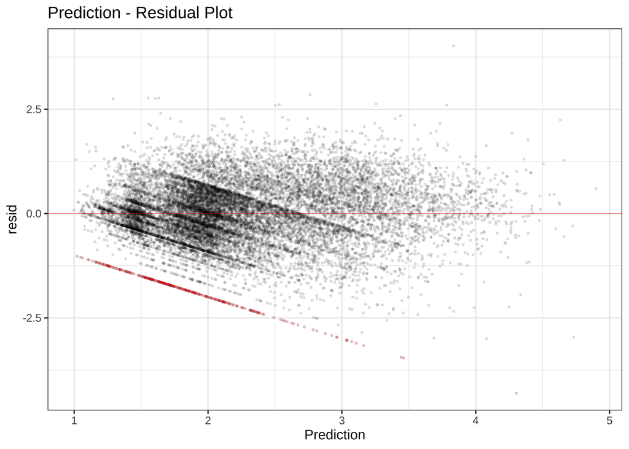

```r
Zero_loss <- Fitted %>%
  mutate(resid = 재산피해금액 - Prediction)%>%
  filter(재산피해금액 == 0)

 p <- Fitted %>%
  mutate(resid = 재산피해금액 - Prediction)%>%
  ggplot() +
  geom_point(aes(x = Prediction, y = resid), alpha = 0.1, size = 0.5)+
  geom_abline(slope = 0, color = "red", size = 0.1)+
  geom_point(data = Zero_loss, aes(x = Prediction, y = resid), alpha = 0.1, color = "red", size = 0.5)+
  theme_bw() +
  ggtitle("Prediction - Residual Plot")

 p
```

```r
ggsave("/Users/donghyunpark/Documents/Seoul National University/3rd year 1st semester/Data mining/1차 프로젝트/1차 프로젝트 Rmd/1차 프로젝트 Visualize/Prediction-Residual.png", plot = p, width = 4, height = 2, dpi = 300)
```

```r
resid <- Fitted$재산피해금액 - Fitted$Prediction

ad.test(resid)
```

```
##
##  Anderson-Darling normality test
##
## data:  resid
## A = 20.424, p-value < 2.2e-16
```